# South African Youth Employment Challenge Project

Aiden Liu

8/21/2019

## Employment Challenge Project

This is a project I took on when I was attending the iXperience Program, learning about Data Science in Cape Town, South Africa. There is currently a youth employment crisis in South Africa, with more than 27% of the youth being unemployed. By utilizing various Data Science techniques, this Employment Challenge Project aims to achieve 2 objectives:

1. Predict who is likely to be in work based on the given data
2. Produce insights on both the South African youth and the South African job market to help Harambee think about interventions (Harambee is an organization focused on solving the Youth Unemployment issue in South Africa “https://harambee.co.za/”)

## About the Data

A longitudinal dataset (for at least some individuals). There are 83,270 observations in the training data set (which is a csv file in this repo). Data is collected at a ‘baseline’ where people are asked about their current circumstances and do some tests. They are then contacted periodically after that and asked about their labour market status.

## Data collected from tests

There is data from five separate tests (each in a separate csv file). These are:

- CFT: a measure of fluid intelligence (or ability);
- COM: a measure of ability to communicate in English;
- NUM: a measure of numerical ability;
- GRIT: a score for ‘grit’ or resilience;
- OPT: a measure of a person’s optimism.

## Data collected at ‘baseline’

- gender (male or female, extracted from the SA ID number. People without a South African ID number will most likely be NA since the scripts to parse the number will fail).
- dob (date of birth, anonimised to the first of the month).
- province (where the respondent was living at time of registration).
- volunteer (whether the person did any volunteering currently or in the past).
- leadershiprole (whether the person has had any leadership role, for example in the church, or on a sports team).
- peoplelive (how many people live together in the household, excludes the respondent).
- peoplelive_15plus (how many of these people are 15 years or older).
- numchildren (number of children the person has).
- numearnincome (number of people who earn income in the household).
- anygrant (whether the household receives any social grants like the child support grant, disability grant or old age pension. South African households are often multiple generations and so young people can be living with their grandparents who receive a state pension).
- anyhhincome (whether the household receives any income).
- financial_situation_now (how the person perceives their current financial situation).
- financial_situation_5years (what the person thinks their financial situation will be like in 5 years’ time).
- givemoney_yes (whether they give money to other people, like their family).

## Data collected from follow-up surveys

People are then contacted periodically (at about 4 monthly intervals) and asked about their current labour market status.

These variables are:

- survey_date_month (month and year survey takes place).
- survey_num (the number of the survey after the ‘baseline’ i.e. survey_num==1 would be the first survey after baseline).
- working (whether a person is working or not at the time of the survey).
- job_start_date (when the person started the job).
- job_leave_date (the date they left their last job: sometimes it is entered as the current date if they are still working).
- company_size (the size of the company someone is working at).
- monthly_pay (the monthly pay range if someone is working).

## Reading in Data

```r
# Reading data
df <- read.csv("data/raw/teaching_training_data.csv")

# Reading in data for each assessment

# test for cognitive fluency
df_cft <- read.csv("data/raw/teaching_training_data_cft.csv")
# communication ability
df_com <- read.csv("data/raw/teaching_training_data_com.csv")
# grit
df_grit <- read.csv("data/raw/teaching_training_data_grit.csv")
# numeracy
df_num <- read.csv("data/raw/teaching_training_data_num.csv")
# optimism
df_opt <- read.csv("data/raw/teaching_training_data_opt.csv")
```

```r
# Each individual should only have one assessment
# set up the data so this is the case
# Also need to only keep the unid and score
df_cft <- df_cft %>%
  select(unid, cft_score) %>%
  distinct(unid, .keep_all = TRUE)

# I want to do this for all 5 asssessments
# keep_all keeps the rest of the variables in the data frame instead of just the unid, in this case, keep the scores as well
helper_function <- function(file_name) {
  file_name %>%
    select(2:3) %>%
    distinct(unid, .keep_all = TRUE)
}
df_opt <- helper_function(df_opt)
df_com <- helper_function(df_com)
df_grit <- helper_function(df_grit)
df_num <- helper_function(df_num)
```

```r
# Adding assessment columns to dataframe
# full_join retains the number of rows in the dataframe
df_assess <- full_join(df_cft, df_com, by ="unid")
df_assess <- df_assess %>%
  full_join(df_grit, by ="unid") %>%
  full_join(df_num, by ="unid") %>%
  full_join(df_opt, by ="unid")
df <- full_join(df, df_assess, by ="unid")
```

## Data Cleaning Process

```r
# Since I am only interested in one single row entry of each individual
# hence I removed repeating survey number (survey_num >= 2)
df_cleaned <- df %>% distinct(unid, .keep_all = TRUE)
```

```r
# Adding age column to the dataframe as I thought it is an important feature to consider
df_cleaned <- df_cleaned %>%
  mutate(age_at_survey = (interval(dob, survey_date_month)/years(1))) %>%
  mutate(age = floor(age_at_survey) )
df <- df %>%
  mutate(age_at_survey = (interval(dob, survey_date_month)/years(1))) %>%
  mutate(age = floor(age_at_survey) )
```

```r
# Again, since I am only interested in one single row entry of each individual
# I removed the post-survey columns (data collected post first survey)
# as I would not need these features in my working predictions
# These include columns stated above such as monthly_pay and company_size
df_cleaned <- subset(df_cleaned, select = -c(X,survey_num,job_start_date,job_leave_date,company_size,monthly_pay))
```

```r
# Checking the percentage of missing values in each column
# Deciding a threshold of percentage of missing values, in this case it is 60%
# and then delete columns that has more than 60% missing values, as I decided that
# there is simply not enough data for the feature to be useful in my working prediction
(colSums(is.na(df_cleaned))*100)/dim(df_cleaned)[1]
```

```
##                       unid          survey_date_month
##                 0.00000000                 0.00000000
##                     gender                        dob
##                 0.04486754                 0.31407280
##                   province                    working
##                62.51024150                 0.00000000
##                  volunteer             leadershiprole
##                37.86040342                37.86040342
##                 peoplelive          peoplelive_15plus
##                37.83114198                76.56938863
##                numchildren              numearnincome
##                38.10229800                63.33736491
##                   anygrant                anyhhincome
##                10.17127697                10.17127697
##    financial_situation_now financial_situation_5years
##                39.81311693                39.81311693
##              givemoney_yes                  cft_score
##                39.17911904                35.85892084
##                  com_score                 grit_score
##                62.25859311                 0.00000000
##                  num_score                  opt_score
##                77.93102103                39.81311693
##              age_at_survey                        age
##                 0.31407280                 0.31407280
```

```r
# Remove columns 'province', 'peoplelive_15plus', 'numearnincome', 'com_score', 'num_score'
# Also remove columns 'age_at_survey', 'dob', 'survey_date_month' as they are irrelevant to my prediction since the age column has already been created
df_cleaned <- subset(df_cleaned, select = -c(peoplelive_15plus, num_score, province, numearnincome, com_score, age_at_survey, dob, survey_date_month))
```

```r
(colSums(is.na(df_cleaned))*100)/dim(df_cleaned)[1]
```

```
##                       unid                     gender
##                 0.00000000                 0.04486754
##                    working                  volunteer
##                 0.00000000                37.86040342
##             leadershiprole                 peoplelive
##                37.86040342                37.83114198
##                numchildren                   anygrant
##                38.10229800                10.17127697
##                anyhhincome    financial_situation_now
##                10.17127697                39.81311693
## financial_situation_5years              givemoney_yes
##                39.81311693                39.17911904
##                  cft_score                 grit_score
##                35.85892084                 0.00000000
##                  opt_score                        age
##                39.81311693                 0.31407280
```

```r
# First noticed that the percentages of NAs in 'volunteer' and 'leadershiprole' are the same
# Hence, filter out rows with NAs in both columns --> did not impute as they are binary variables
df_cleaned <- df_cleaned %>% filter(!is.na(volunteer))

# Similar case happens for rows in 'financial_situation_now' & 'financial_situation_5years'
# Hence, filter out those rows with NAs in both columns
df_cleaned <- df_cleaned %>% filter(!is.na(financial_situation_now))
```

```r
# Double check the % of NAs in those filtered columns
(colSums(is.na(df_cleaned))*100)/dim(df_cleaned)[1]
```

```
##                       unid                     gender
##                  0.0000000                  0.0000000
##                    working                  volunteer
##                  0.0000000                  0.0000000
##             leadershiprole                 peoplelive
##                  0.0000000                  0.0000000
##                numchildren                   anygrant
##                  0.1231647                  0.0000000
##                anyhhincome    financial_situation_now
##                  0.0000000                  0.0000000
## financial_situation_5years              givemoney_yes
##                  0.0000000                  2.2461349
##                  cft_score                 grit_score
##                 25.3265485                  0.0000000
##                  opt_score                        age
##                  0.0000000                  0.0129647
```

```r
# 'numchildren' has 0.12% NAs and 'givemoney_yes' has 2.25% NAs, hence filter rows with NAs in those out
# 'age' has 0.013% NAs and hence filter rows with NAs in 'age' out as well
# Again, I'm following the rule of not imputing any binary/categorical variables
df_cleaned <- df_cleaned %>% filter(!is.na(numchildren)) %>% filter(!is.na(givemoney_yes)) %>% filter(!is.na(age))
```

```r
# Only 'cft_score' column has NAs now
(colSums(is.na(df_cleaned))*100)/dim(df_cleaned)[1]
```

```
##                       unid                     gender
##                    0.00000                    0.00000
##                    working                  volunteer
##                    0.00000                    0.00000
##             leadershiprole                 peoplelive
##                    0.00000                    0.00000
##                numchildren                   anygrant
##                    0.00000                    0.00000
##                anyhhincome    financial_situation_now
##                    0.00000                    0.00000
## financial_situation_5years              givemoney_yes
##                    0.00000                    0.00000
##                  cft_score                 grit_score
##                   24.49034                    0.00000
##                  opt_score                        age
##                    0.00000                    0.00000
```

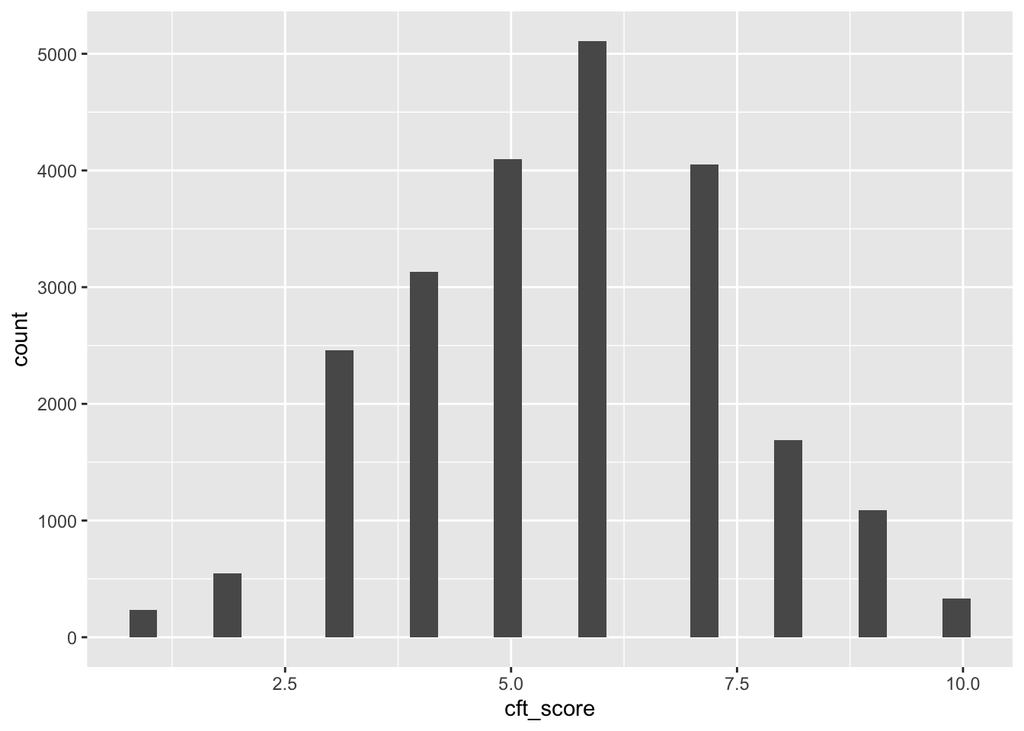

```r
# Since there is roughly about 25% of NAs in 'cft_score', I chose to impute this variable
# First plotting the histogram of cft_score
ggplot(df_cleaned, aes(x=cft_score)) + geom_histogram()
```

```r
# This is a normal distribution with no extreme outliners, I chose to impute with mean
df_cleaned$cft_score[is.na(df_cleaned$cft_score)] <- mean(df_cleaned$age, na.rm = TRUE)
```

```r
# Always good to double check again if every column is filled
(colSums(is.na(df_cleaned))*100)/dim(df_cleaned)[1]
```

```
##                       unid                     gender
##                          0                          0
##                    working                  volunteer
##                          0                          0
##             leadershiprole                 peoplelive
##                          0                          0
##                numchildren                   anygrant
##                          0                          0
##                anyhhincome    financial_situation_now
##                          0                          0
## financial_situation_5years              givemoney_yes
##                          0                          0
##                  cft_score                 grit_score
##                          0                          0
##                  opt_score                        age
##                          0                          0
```

## Working Prediction Approch: Simple GLM model

Since the nature of the variable I am predicting is binary (working/not working), it makes sense to use a logistic regression (GLM) model from the caret package.

```r
# Splitting data into training and testing dataset, with a 80-20 split
trainRowNumbers <- createDataPartition(df_cleaned$working, p=0.8, list=FALSE)
trainData <- df_cleaned[trainRowNumbers,]
testData <- df_cleaned[-trainRowNumbers,]

# Cross-validation
trControl <- trainControl(method = "cv", number = 10, verboseIter = TRUE)

# GLM model on cleaned dataframe (df)
model_glm <- train(as.factor(working) ~ ., data=trainData, method='glm', trControl = trControl)
predicted_glm <- predict(model_glm, testData)
model_glm
```

```
## Generalized Linear Model
##
## 24096 samples
##    15 predictor
##     2 classes: 'FALSE', 'TRUE'
##
## No pre-processing
## Resampling: Cross-Validated (10 fold)
## Summary of sample sizes: 21686, 21686, 21686, 21686, 21686, 21687, ...
## Resampling results:
##
##   Accuracy   Kappa
##   0.7627407  -0.0000829456
```

```r
caret::confusionMatrix(as.factor(predicted_glm), as.factor(testData$working))
```

```
## Confusion Matrix and Statistics
##
##           Reference
## Prediction FALSE TRUE
##      FALSE  4594 1428
##      TRUE      0    0
##
##                Accuracy : 0.7629
##                  95% CI : (0.7519, 0.7736)
##     No Information Rate : 0.7629
##     P-Value [Acc > NIR] : 0.5071
##
##                   Kappa : 0
##
##  Mcnemar's Test P-Value : <0.0000000000000002
##
##             Sensitivity : 1.0000
##             Specificity : 0.0000
##          Pos Pred Value : 0.7629
##          Neg Pred Value :    NaN
##              Prevalence : 0.7629
##          Detection Rate : 0.7629
##    Detection Prevalence : 1.0000
##       Balanced Accuracy : 0.5000
##
##        'Positive' Class : FALSE
##
```

## Improved Approach of GLM model

I noticed that the confusion matrix of the prediction is not ideal, as it is simply predicting all false, which also means that the probability of individuals in this data being in work is always less than 50%. Therefore, I decided to change the threshold of my working prediction, meaning to adjust the probability of individuals working such that those who have probabilities of above 30% are predicted as working.

```r
model_glm_alt <- glm(as.factor(working) ~ ., data=testData, family = binomial("logit"))
model_glm_alt_pred <- as.data.frame(predict(model_glm_alt, data = testData, type = 'response')) %>% rename(pred = 'predict(model_glm_alt, data = testData, type = \"response\")')
model_glm_alt_pred <- bind_cols(testData, model_glm_alt_pred)
model_glm_alt_pred <- model_glm_alt_pred %>% mutate(binary_pred = case_when(pred >= 0.30 ~TRUE, pred < 0.30 ~FALSE))
confusionMatrix(as.factor(model_glm_alt_pred$binary_pred), as.factor(testData$working))
```

```
## Confusion Matrix and Statistics
##
##           Reference
## Prediction FALSE TRUE
##      FALSE  4052 1179
##      TRUE    542  249
##
##                Accuracy : 0.7142
##                  95% CI : (0.7026, 0.7256)
##     No Information Rate : 0.7629
##     P-Value [Acc > NIR] : 1
##
##                   Kappa : 0.0666
##
##  Mcnemar's Test P-Value : <0.0000000000000002
##
##             Sensitivity : 0.8820
##             Specificity : 0.1744
##          Pos Pred Value : 0.7746
##          Neg Pred Value : 0.3148
##              Prevalence : 0.7629
##          Detection Rate : 0.6729
##    Detection Prevalence : 0.8686
##       Balanced Accuracy : 0.5282
##
##        'Positive' Class : FALSE
##
```

## Explanation of improvement of the model

Although it is true that the accuracy of the modified model went down, however in this case, I am actually increasing the specificty and predicting more TRUE (working) results. This can be argued that is a better approach than the orginial GLM model despite the decrease in accuracy

## Insights

As mentioned above, the rows with NA values in the column ‘volunteer’ also has NA values in ‘leadershiprole’. It is interesting to me how there are columns that have the exact same pattern as the two mentioned above. Specifically, they are ‘anyhhincome’ and ‘anygrant’. To me, this is no coincidence, hence I wanted to look more into it and hopefully draw some insights about these particular columns.

### Insight 1: Outside Activities v.s Working

```r
# combining the columns 'volunteer' and 'leadershiprole' into one column 'out_acti' which stands for outside activities, and it is binary (TRUE when individual has either, FALSE otherwise)
df <- df %>% mutate(out_acti = case_when((df$volunteer == 'Yes' | df$leadershiprole == 'Yes') ~ 'TRUE',
                                         (df$volunteer == 'No' | df$leadershiprole == 'No' ~ 'FALSE')))
df_out_acti <- df %>% filter(!is.na(out_acti))

# the regression model shows that additional 2% chance of working if one has volunteer and/or leadership experience
reg_out_acti = lm(working ~ out_acti, data = df_out_acti)
summary(reg_out_acti)
```

```
##
## Call:
## lm(formula = working ~ out_acti, data = df_out_acti)
##
## Residuals:
##     Min      1Q  Median      3Q     Max
## -0.2743 -0.2743 -0.2505  0.7257  0.7495
##
## Coefficients:
##              Estimate Std. Error t value             Pr(>|t|)
## (Intercept)  0.250458   0.002944  85.063 < 0.0000000000000002 ***
## out_actiTRUE 0.023801   0.003921   6.071        0.00000000128 ***
## ---
## Signif. codes:  0 '***' 0.001 '**' 0.01 '*' 0.05 '.' 0.1 ' ' 1
##
## Residual standard error: 0.4406 on 51347 degrees of freedom
## Multiple R-squared:  0.0007172,  Adjusted R-squared:  0.0006977
## F-statistic: 36.85 on 1 and 51347 DF,  p-value: 0.000000001284
```

### Inisight 1 Conclusion

Firstly, it is important to point out that ‘volunteer’ in the South African context is a little bit different from the States and the rest of the world. Due to the high level of unemployment in South Africa, volunteering is often referred to as jobless people helping out in events that are short of staff, and they get paid from doing so. Hence, often times, people without a job would simply go around ‘volunteering’ for events and that is how they make a living. Though ‘volunteering’ here is used in a different context, nonetheless, it is also part of a working experience and should not be taken lightly. Since there is an additional 2% chance of youth working if he/she happens to have volunteering or a leadership experience, Harambee would be able to intervene by designing courses or create platforms for such experiences to be had for youth.

### Insight 2: External Support v.s Working

```r
# combining columns 'anygrant' and 'anyhhincome' into one column 'ext_supp' which stands for external support, and it is binary (TRUE when individual has either, FALSE otherwise)
df <- df %>% mutate(ext_supp = case_when((df$anygrant == 'TRUE' | df$anyhhincome == 'TRUE') ~ 'TRUE',
                                         (df$anygrant == 'FALSE' | df$anyhhincome == 'FALSE' ~ 'FALSE')))
df_ext_supp <- df %>% filter(!is.na(ext_supp))

# the regression model shows that additional 7% chance of working if one has external support
reg_ext_supp = lm(working ~ ext_supp, data = df)
summary(reg_ext_supp)
```

```
##
## Call:
## lm(formula = working ~ ext_supp, data = df)
##
## Residuals:
##     Min      1Q  Median      3Q     Max
## -0.2631 -0.2631 -0.1927 -0.1927  0.8073
##
## Coefficients:
##              Estimate Std. Error t value            Pr(>|t|)
## (Intercept)  0.192730   0.002518   76.53 <0.0000000000000002 ***
## ext_suppTRUE 0.070380   0.003184   22.10 <0.0000000000000002 ***
## ---
## Signif. codes:  0 '***' 0.001 '**' 0.01 '*' 0.05 '.' 0.1 ' ' 1
##
## Residual standard error: 0.4237 on 75599 degrees of freedom
##   (7669 observations deleted due to missingness)
## Multiple R-squared:  0.006421,   Adjusted R-squared:  0.006408
## F-statistic: 488.5 on 1 and 75599 DF,  p-value: < 0.00000000000000022
```

### Insight 2 Conclusion

Based on the regression model, there is a 7 percentage points increase if one has external support, receiving funding in one way or another. It is however, extremely significant as it is a roughly 36% rise from one not having external support (19% probability of working) to one having external support (26% probability of working). I believe the reason for such a notable difference is because for families that has household income, the working people could perhaps have better connections and also a better understand the current status of the job market, in terms of any potential job openings or even just the basic understanding of what it takes to land a job. In a family-oriented society like South Africa’s, having people in the family working is definitely a huge factor in one landing a job. In additon, from my own experiences of hearing stories from the local South Africans, the South African families would often spend money to print out flyers/resumes to go around and advertise themselves. This is made easier with any form of external support. It is very interesting how South African families utilize their external support and I think it deserves further research in order to come up with great interventions.

### Insight 3: Age & Gender v.s Working

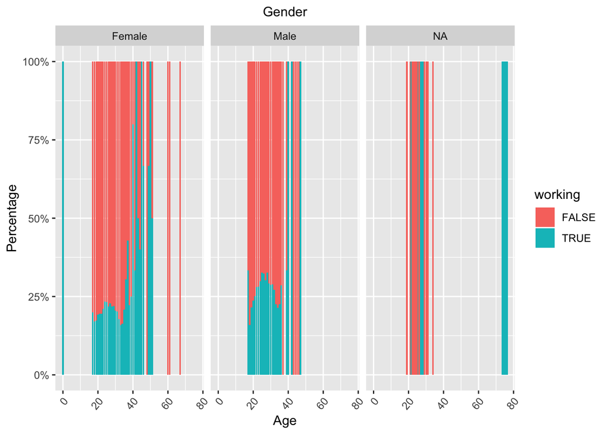

```r
# Plotting a graph showing percentage of females and males working based on their age using ggplot
ggplot(data = df, aes(x = age)) +
  geom_bar(aes(fill = working), position = "fill") + facet_grid(~gender) +
  theme(axis.text.x = element_text(angle = 50, hjust =1)) +
  ylab("Percentage") + xlab("Age") +
  labs(subtitle = "Gender") + theme(plot.subtitle = element_text(hjust = 0.5)) +
  scale_y_continuous(labels=scales::percent)
```

### Insight 3 Conclusion

This is a plot of the percentage of females and males working at different ages. The graphs are somewhat telling but not entirely accurate. Firstly, it can be noticed that more males are in work in general as seen by the higher green bars on the right of the plot. Secondly, similar to both females and males, the optimal age range to be employed is around 24-30 years old as there is a slight rise in the percentage of females/males that are employed. I am only focusing on the age range between 18-35 (youth). The green bars that are above 50% are not exactly telling as often times, there are only so few data points of people at that particular age so if they are working, it would yield a 100% rate of working. The conclusion here is that a higher percentage of males are employed more than females and most youth workers are between the age of 24-30 years old. I believe Harambee would be able to take this information and do further research on the characteristics of the youth in that particlar age range (24-30) to understand why they have a higher chance of getting employed, as well as to find out the difference in the characteristics between the male and female youth.

### Insight 4: Province v.s Working

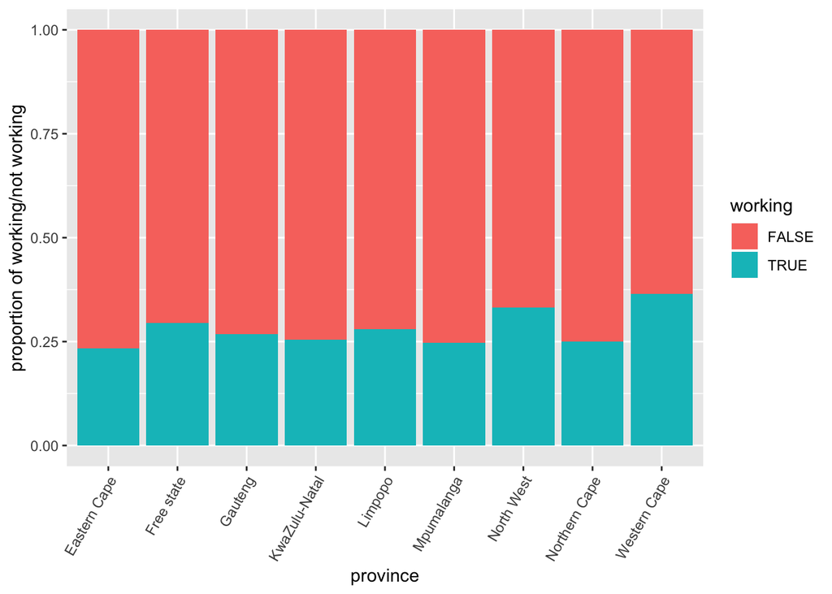

```r
# Plotting a graph showing percentage of people working based on their province using ggplot
ggplot(data = df %>% filter(!is.na(province)), aes(x = province)) +
  geom_bar(aes(fill = working), position = 'fill') +
  theme(axis.text.x = element_text(angle = 60, hjust = 1)) +
  ylab('proportion of working/not working')
```

## Project Conclusion

As my first Data Science Project, I have definitely learned a ton from this experience. As I reflect upon the result/insights that I obtained, I feel that it is important to point out ways perhaps I could have done better in terms of my prediction and insights.

The provided data has about 76% of the people not working and only about 24% of the people working. In other words, the data is rather skewed. This is the reason why I decided to lower the threshold to predicting working to below 30% in my improved GLM model. One thing I could have done to make my prediction better is perhaps add a heavier weight and emphasize the individuals who are working, and to highlgiht the variables that make them better candidates to be employed. This will be part of my further research, by learning techniques to refine and fine-tune my predictions.

In terms of the insights, I believe I can dive into further research and spend more time finding evidence to backup my findings and perhaps think of ways that Harambee could intervene. As I get more familiar with R, I also think that there may be some insights to be drawn from the data collection process, and advice Harambee on how it can better collect its data to yield a more accurate prediction.